# AMS Data1

## Assignment 4: Transport

###### © Group 3 - Lena Gerstmans, Henrike Beckeveld & Tess van den Berg

##### **Link back to our webstite:** *https://tessvdberg.github.io/thisisgroup3.github.io/*

##### **Link to our jupyter notebooks:** *https://github.com/Tessvdberg/thisisgroup3.github.io*

## Paralympics

Paris is hosting the Paralympics in 2024. One of the events at the Paralympics is an open water swimming event in the Seine (apparently the water is clean or so the French say). Since the City of Amsterdam thinks it is beter than Paris, they want to host an event before the Paralympics, snubbing the Parisians. The idea is to host a 5km. open water swimming event through the canals of Amsterdam. You are asked by the municipality of Amsterdam to advise on the feasibility of the event from the perspective of the safety of the partaking athletes from an environmental perspective. The event is going to be hosted in May.

The Municipality wants you to find a location for the Event Headquarters. They decided it would be best if this E.H. is as close to the centre of the swimming route. There is a bit of a concern for the after party and the stream of visitors. They want you to quantify the number o visitors that can reach the event and the capacity for festivites after the even*.

### Assignment 4

Since we were not able to base our route upon water pollution, the existing route of the City Swim was taken as a start, as we knew there would be pollution level installations. The remaining route has been based upon accessibility for paralympic swimmers and the public. In addition, only a part of the Herengracht and Keizersgracht is used for the event. This means the canal boats can still go through the popular canals.

Show we used these codes below to plot our routeer:

```python
#libraries used:
import osmnx as ox
import networkx as nx
import matplotlib.pyplot as plt
from geopy.distance import geodesic
import overpy
```

```python
#This code calculates our route

coordinates = [(52.373019, 4.914070), (52.369720, 4.910826), (52.365878, 4.921393), (52.363392, 4.915889), (52.365756, 4.908859), (52.366905, 4.884810), (52.366152, 4.882775), (52.361609, 4.896081)]

# Calculate the total distance in kilometers
total_distance = 0
for i in range(len(coordinates) - 1):
    total_distance += geodesic(coordinates[i], coordinates[i+1]).kilometers

print(f"Total distance: {total_distance} kilometers")
```

```
Total distance: 5.120821020971287 kilometers
```

To calcualte this route in Python:

```python
#To set the 'centre' waterways of Amsterdam random adresses were taken to set the boundaries

coordinates_north = ox.geocode("Asterweg 22, Amsterdam, Netherlands")
print(f'north: {coordinates_north}')
coordinates_south = ox.geocode("Cornelis Troostplein 21, Amsterdam, Netherlands")
print(f'south: {coordinates_south}')
coordinates_east = ox.geocode("Jacob Van Lennepkade 215, Amsterdam, Netherlands")
print(f'east: {coordinates_east}')
coordinates_west = ox.geocode("Azartplein 2-A, Amsterdam, Netherlands")
print(f'west: {coordinates_west}')
```

```
north: (52.3911937, 4.9040367)
south: (52.3505111, 4.8911488)
east: (52.3623344, 4.8618788)
west: (52.376525, 4.9380764)
```

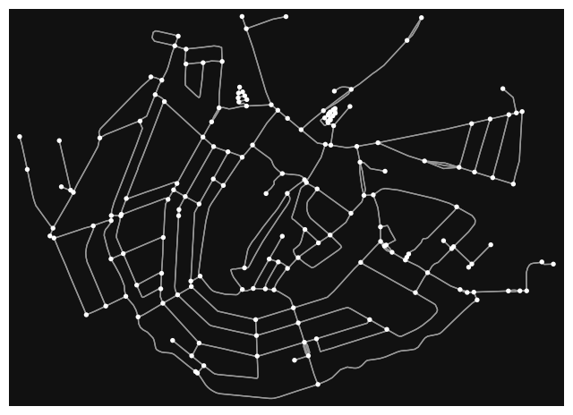

```
Point (52.3715052, 4.9132839) is closest to node 331854233
Point (52.3699182, 4.9103143) is closest to node 323929882
Point (52.3673803, 4.9184649) is closest to node 3781170134
Point (52.363902, 4.9144547) is closest to node 252100239
Point (52.3647776, 4.9118301) is closest to node 178287360
Point (52.3647402, 4.9029135) is closest to node 178249906
Point (52.3635193, 4.8965476) is closest to node 178261156
Point (52.3668675, 4.8850865) is closest to node 60740852
Point (52.3661325, 4.8828656) is closest to node 60742002
Point (52.3628662, 4.8877174) is closest to node 117738503
Point (52.3616157, 4.8960296) is closest to node 117738509
<class 'dict_values'>
dict_values([331854233, 323929882, 3781170134, 252100239, 178287360, 178249906, 178261156, 60740852, 60742002, 117738503, 117738509])
```

```python
#In this code, we specify the bounding box using latitude and longitude coordinates (north, south, east, west) to focus on the center of Amsterdam. The ox.graph_from_bbox function is used to retrieve the graph for the specified bounding box.
import osmnx as ox
import networkx as nx
import matplotlib.pyplot as plt

startingpoint = (52.3714489, 4.9137137)
point1 = (52.369720, 4.910826)
point2 = (52.365878, 4.921393)
point3 = (52.363392, 4.915889)
point4 = (52.365756, 4.908859)
point5 = (52.366905, 4.884810)
point6 = (52.366152, 4.882775)
endingpoint = (52.361609, 4.896081)

import osmnx as ox
import networkx as nx
import matplotlib.pyplot as plt

ox.settings.use_cache = True
ox.settings.log_console = True
north, south, east, west = 52.3911937, 52.3505111, 4.8618788, 4.9380764
graph_waterways_centre = ox.graph_from_bbox(north, south, east, west, network_type='all', simplify=True, custom_filter='["waterway"~"river|canal"]')
fig, ax = ox.plot_graph(graph_waterways_centre)

#The latitude and longitude points were retrieved from Google maps
points = [
    (52.3715052, 4.9132839),
    (52.3699182, 4.9103143),
    (52.3673803, 4.9184649),
    (52.3639020, 4.9144547),
    (52.3647776, 4.9118301),
    (52.3647402, 4.9029135),
    (52.3635193, 4.8965476),
    (52.3668675, 4.8850865),
    (52.3661325, 4.8828656),
    (52.3628662, 4.8877174),
    (52.3616157, 4.8960296)
]

nearest_nodes_dict = {}
for point in points:
    lat, lon = point
    nearest_node = ox.distance.nearest_nodes(graph_waterways_centre, X=lon, Y=lat)
    nearest_nodes_dict[point] = nearest_node

for point, nearest_node in nearest_nodes_dict.items():
    print(f"Point {point} is closest to node {nearest_node}")
values = nearest_nodes_dict.values()
print(type(values))
print(nearest_nodes_dict.values())
```

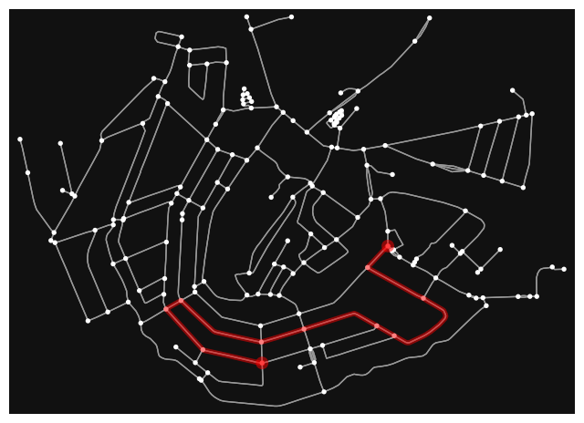

```python
pt = ox.graph_to_gdfs(graph_waterways_centre, edges=False).unary_union.centroid
path = [331854233, 323929882, 3781170134, 252100239, 178287360, 178249906, 178261156, 60740852, 60742002, 117738503, 117738509]
fig, ax = ox.plot_graph_route(graph_waterways_centre, path)
```

#### Question 1 - Find the centre of the nodes of the swimming route. See this link.

#### Answer 1.

The centre of the nodes of the swimming route was calculated by finding the central latitude and longitude points. Then, it was illustrated by finding the corresponding node of this coordinate. The map on which this is illustrated is of the road network of the centre of Amsterdam for easy readability.

```python
#Find the centre of the nodes of the swimming route
import osmnx as ox
coordinates = [
    (52.3715052, 4.9132839),
    (52.3699182, 4.9103143),
    (52.3673803, 4.9184649),
    (52.3639020, 4.9144547),
    (52.3647776, 4.9118301),
    (52.3647402, 4.9029135),
    (52.3635193, 4.8965476),
    (52.3668675, 4.8850865),
    (52.3661325, 4.8828656),
    (52.3628662, 4.8877174),
    (52.3616157, 4.8960296)
]
central_latitude = sum(lat for lat, lon in coordinates) / len(coordinates)
central_longitude = sum(lon for lat, lon in coordinates) / len(coordinates)
print(f'The location of the Head Quarters would be near {central_latitude, central_longitude}')
```

```
The location of the Head Quarters would be near (52.365747700000014, 4.9017734636363635)
```

```
The nearest node to the central coordinate is 46359166
```

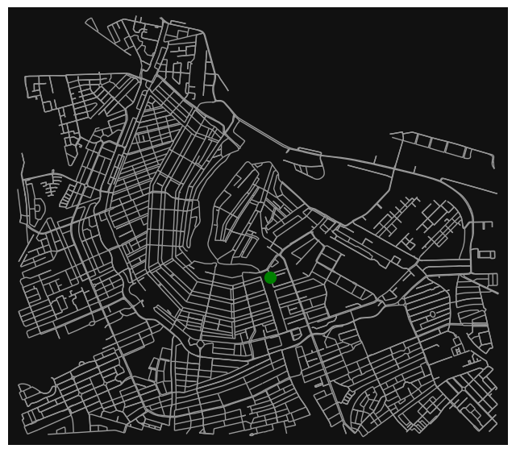

```python
#creating the map with roads to show the location of the head quarters
ox.settings.use_cache = True
ox.settings.log_console = True
north, south, east, west = 52.3911937, 52.3505111, 4.8618788, 4.9380764
custom_filter = '["highway"~"^(motorway|trunk|primary|secondary|tertiary|residential|unclassified|road)$"]'
graph_centre = ox.graph_from_bbox(north, south, east, west, network_type='all', simplify=True, custom_filter=custom_filter)

#To find the nearest node of the head quarter
nearest_central_node = ox.distance.nearest_nodes(graph_centre, central_longitude, central_latitude)
print(f'The nearest node to the central coordinate is {nearest_central_node}')

specific_node = 46359166

# visualise the node in the map
fig, ax = ox.plot_graph(graph_centre, node_color='b', node_size=0, show=False)
node_positions = {node: (data['x'], data['y']) for node, data in graph_centre.nodes(data=True)}
if specific_node in node_positions:
    x, y = node_positions[specific_node]
    ax.scatter(x, y, c='g', s=100, marker='o')

plt.show()
```

#### Question 2 - Use the centre to find a suitable spot for the Event Headquarters.

#### Answer 2.

The central point is located near the Amstel canal, almost exactly on the location of the SWEETS hotel Walter Süskindbrug. This hotel could be used as a headquarter. Additionally, that's great since it looks out over the Amstel and there is a lot of privacy. See image of the hotel.

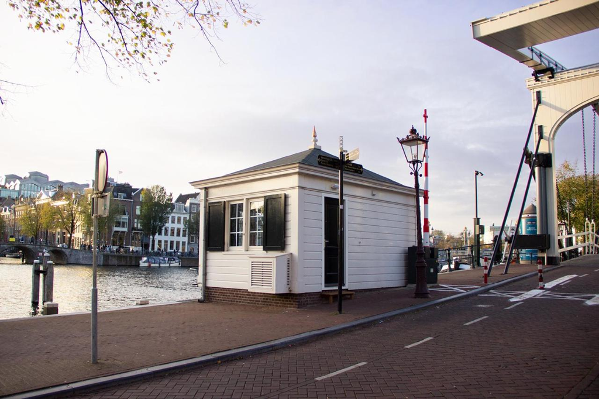

#### Question 3 - Find the closest bus and tram stops at the start and finish of the swimming route..

#### Answer 3.

Using our start pointand finish point we used the code below to find all the bus and tram spots near the start and finish within a 10 minutes walk.

All bus and tram stops near the starting point:

```python
# coordinates start (latitude and longitude)
lat = 52.3715052
lon = 4.9132839

# distance for 10 minute walk:
average_speed = 5040 #m/h
walking_radius = (5040/60)*10
print(walking_radius)

# extracting information about bus and trams stops (ways and nodes)
query = f"""
    [out:json];
    (
        node["public_transport"="stop_position"]
            (around:{walking_radius},{lat},{lon});
        way["public_transport"="platform"]
            (around:{walking_radius},{lat},{lon});
    );
    out center;
"""

api = overpy.Overpass()

result = api.query(query)

# printing the results in a list
for node in result.nodes:
    print(f'Node: {node.tags.get("name", "Unknown")}, Location: ({node.lat}, {node.lon})')

for way in result.ways:
    print(f'Way: {way.tags.get("name", "Unknown")}, Location: ({way.center_lat}, {way.center_lon})')
```

```
840.0
Node: Meester Visserplein, Location: (52.3679611, 4.9053602)
Node: Amsterdam, Prins Hendrikkade, Location: (52.3734630, 4.9065518)
Node: Amsterdam, Piet Heinkade, Location: (52.3773362, 4.9135819)
Node: Muziekgebouw, Location: (52.3772063, 4.9134308)
Node: Amsterdam, Kadijksplein, Location: (52.3709246, 4.9133660)
Node: Artis, Location: (52.3667187, 4.9109550)
Node: Kattenburgerstraat, Location: (52.3760656, 4.9220599)
Node: Amsterdam, Wittenburgergracht, Location: (52.3691024, 4.9207898)
Node: Amsterdam, Wittenburgergracht, Location: (52.3694986, 4.9196296)
Node: Amsterdam, Kadijksplein, Location: (52.3708094, 4.9134932)
Node: Amsterdam, Kattenburgerplein, Location: (52.3706236, 4.9163389)
Node: Amsterdam, Kattenburgerplein, Location: (52.3707527, 4.9159260)
Node: Meester Visserplein, Location: (52.3677535, 4.9058474)
Node: Artis, Location: (52.3665623, 4.9113237)
Node: Plantage Lepellaan, Location: (52.3651045, 4.9155317)
Node: Plantage Lepellaan, Location: (52.3652225, 4.9152768)
Node: Muziekgebouw, Location: (52.3772761, 4.9125470)
Node: Kattenburgerstraat, Location: (52.3761672, 4.9211099)
Node: Jan Schaeferbrug, Location: (52.3765211, 4.9218652)
Node: Amsterdam, Kattenburgerstraat, Location: (52.3727180, 4.9184891)
Node: Amsterdam, Kattenburgerstraat, Location: (52.3722710, 4.9179263)
Node: Amsterdam, Waterlooplein, Location: (52.3687054, 4.9045597)
Node: Amsterdam, IJ tunnel, Location: (52.3722719, 4.9094406)
Node: Amsterdam, Kattenburg, Location: (52.3764724, 4.9205741)
Node: Amsterdam, Kattenburg, Location: (52.3760913, 4.9226998)
Node: Amsterdam, Prins Hendrikkade, Location: (52.3745522, 4.9045236)
Node: Jan Schaeferbrug, Location: (52.3765349, 4.9217586)
Node: Amsterdam, Waterlooplein, Location: (52.3687141, 4.9048175)
Node: Amsterdam, Piet Heinkade, Location: (52.3772270, 4.9140766)
Node: Nieuwmarkt, Location: (52.3713530, 4.9010846)
Node: Waterlooplein, Location: (52.3666905, 4.9037527)
Node: Nieuwmarkt, Location: (52.3714238, 4.9009379)
Node: Amsterdam, Artis, Location: (52.3667085, 4.9109459)
Node: Amsterdam, Plantage Lepellaan, Location: (52.3652107, 4.9152649)
Node: Amsterdam, Artis, Location: (52.3665730, 4.9113349)
Way: Unknown, Location: (52.3772204, 4.9135535)
Way: Unknown, Location: (52.3760551, 4.9224188)
Way: Unknown, Location: (52.3772565, 4.9123966)
Way: Unknown, Location: (52.3761641, 4.9208720)
Way: Unknown, Location: (52.3764852, 4.9208512)
Way: Artis, Location: (52.3666024, 4.9111444)
Way: Meester Visserplein, Location: (52.3678137, 4.9055817)
Way: Artis, Location: (52.3666551, 4.9111893)
Way: Meester Visserplein, Location: (52.3678764, 4.9056682)
Way: Unknown, Location: (52.3651858, 4.9154399)
Way: Unknown, Location: (52.3651371, 4.9153809)
Way: Waterlooplein, Location: (52.3667215, 4.9035699)
Way: Nieuwmarkt, Location: (52.3712539, 4.9009408)
```

The one closest to the start:

```python
# coordinates start (latitude and longitude)
lat = 52.3715052
lon = 4.9132839

# we take 840m for a 10 minute walk
walking_radius = 840

# extracting information about bus and trams stops (ways and nodes)
query = f"""
    [out:json];
    (
        node["public_transport"="stop_position"]
            (around:{walking_radius},{lat},{lon});
        way["public_transport"="platform"]
            (around:{walking_radius},{lat},{lon});
    );
    out center;
"""

api = overpy.Overpass()

result = api.query(query)

closest_stop = None
closest_distance = float('inf')

# finding the nearest stop
for node in result.nodes:
    location = (float(node.lat), float(node.lon))
    distance = ((lat - location[0])**2 + (lon - location[1])**2) ** 0.5
    if distance < closest_distance:
        closest_stop = node
        closest_distance = distance

for way in result.ways:
    location = (float(way.center_lat), float(way.center_lon))
    distance = ((lat - location[0])**2 + (lon - location[1])**2) ** 0.5
    if distance < closest_distance:
        closest_stop = way
        closest_distance = distance

# Print the closest stop
if closest_stop:
    if hasattr(closest_stop, 'tags'):
        name = closest_stop.tags.get("name", "Unknown")
        print(f'Closest Stop: {name}, Location: ({closest_stop.lat}, {closest_stop.lon})')
    else:
        print(f'Closest Stop: Unknown Location: ({closest_stop.center_lat}, {closest_stop.center_lon})')
else:
    print("No nearby bus or tram stops found within the specified radius.")
```

```
Closest Stop: Amsterdam, Kadijksplein, Location: (52.3709246, 4.9133660)
```

The nearest public transport stop to the start is Kadijksplein (52.3709246, 4.9133660). We use this stop for our next calculations in Assignment 4.

All bus and tram stops near the finish:

```python
# coördinates finish
lat = 52.361609
lon = 4.896081

# we take 840m for a 10 minute walk
walking_radius = 840

# extracting information about bus and trams stops (ways and nodes)
query = f"""
    [out:json];
    (
        node["public_transport"="stop_position"]
            (around:{walking_radius},{lat},{lon});
        way["public_transport"="platform"]
            (around:{walking_radius},{lat},{lon});
    );
    out center;
"""

api = overpy.Overpass()

result = api.query(query)

# printing the results in a list
for node in result.nodes:
    print(f'Node: {node.tags.get("name", "Unknown")}, Location: ({node.lat}, {node.lon})')

for way in result.ways:
    print(f'Way: {way.tags.get("name", "Unknown")}, Location: ({way.center_lat}, {way.center_lon})')
```

```
Node: Waterlooplein, Location: (52.3669934, 4.9019846)
Node: Rijksmuseum, Location: (52.3609734, 4.8871040)
Node: Vijzelgracht, Location: (52.3599031, 4.8909623)
Node: Keizersgracht, Location: (52.3638329, 4.8983188)
Node: Frederiksplein, Location: (52.3601777, 4.8992936)
Node: Stadhouderskade, Location: (52.3581612, 4.8992468)
Node: Van Woustraat, Location: (52.3546903, 4.9008616)
Node: Van Woustraat, Location: (52.3549446, 4.9015849)
Node: Keizersgracht, Location: (52.3659309, 4.8863435)
Node: Weesperplein, Location: (52.3610021, 4.9071213)
Node: Vijzelgracht, Location: (52.3595051, 4.8921024)
Node: Rembrandtplein, Location: (52.3662601, 4.8964238)
Node: Waterlooplein, Location: (52.3671715, 4.9022284)
Node: Vijzelgracht, Location: (52.3600132, 4.8910303)
Node: Keizersgracht, Location: (52.3637916, 4.8982915)
Node: Frederiksplein, Location: (52.3590024, 4.8989049)
Node: Ceintuurbaan, Location: (52.3550346, 4.9010669)
Node: Rembrandtplein, Location: (52.3662292, 4.8968199)
Node: Keizersgracht, Location: (52.3659919, 4.8865383)
Node: Frederiksplein, Location: (52.3594109, 4.8978483)
Node: Rijksmuseum, Location: (52.3608307, 4.8873395)
Node: Amsterdam, Ferdinand Bolstraat, Location: (52.3579917, 4.8918514)
Node: Amsterdam, Weesperplein, Location: (52.3614715, 4.9077118)
Node: Amsterdam, Ruysdaelkade, Location: (52.3602454, 4.8865615)
Node: Amsterdam, Ruysdaelkade, Location: (52.3603257, 4.8865688)
Node: Amsterdam, Ferdinand Bolstraat, Location: (52.3579616, 4.8923047)
Node: Marie Heinekenplein, Location: (52.3570037, 4.8907033)
Node: Muntplein, Location: (52.3662653, 4.8931342)
Node: Muntplein, Location: (52.3658545, 4.8930583)
Node: Marie Heinekenplein, Location: (52.3571177, 4.8907718)
Node: Prinsengracht, Location: (52.3620972, 4.8989490)
Node: Prinsengracht, Location: (52.3621338, 4.8989773)
Node: Vijzelgracht, Location: (52.3606866, 4.8910469)
Node: Vijzelgracht, Location: (52.3606661, 4.8912207)
Node: Frederiksplein, Location: (52.3596835, 4.9000102)
Node: Vijzelgracht, Location: (52.3594772, 4.8925358)
Node: Amsterdam, Van Woustraat, Location: (52.3547009, 4.9008536)
Node: Amsterdam, Van Woustraat, Location: (52.3549349, 4.9015938)
Node: Amsterdam, Ceintuurbaan, Location: (52.3550383, 4.9010846)
Node: Waterlooplein, Location: (52.3666363, 4.9036061)
```

[output cut: 44 more lines]

```
Way: Prinsengracht, Location: (52.3621838, 4.8989924)
Way: Vijzelgracht, Location: (52.3606362, 4.8911298)
Way: Unknown, Location: (52.3609486, 4.8872320)
Way: Unknown, Location: (52.3608220, 4.8873252)
Way: Unknown, Location: (52.3546102, 4.9006790)
Way: Unknown, Location: (52.3550472, 4.9018317)
Way: Prinsengracht, Location: (52.3620605, 4.8990412)
Way: Prinsengracht, Location: (52.3621241, 4.8990161)
Way: Prinsengracht, Location: (52.3620403, 4.8989372)
Way: Prinsengracht, Location: (52.3621050, 4.8989117)
Way: Keizersgracht, Location: (52.3638703, 4.8982318)
Way: Keizersgracht, Location: (52.3637172, 4.8982908)
Way: Keizersgracht, Location: (52.3637457, 4.8983835)
Way: Keizersgracht, Location: (52.3638981, 4.8983261)
Way: Muntplein, Location: (52.3657172, 4.8930505)
```

```python
import overpy
# coördinates finish
lat = 52.360482
lon = 4.899595

# we take 840m for a 10 minute walk
walking_radius = 840

# extracting information about bus and trams stops (ways and nodes)
query = f"""
    [out:json];
    (
        node["public_transport"="stop_position"]
            (around:{walking_radius},{lat},{lon});
        way["public_transport"="platform"]
            (around:{walking_radius},{lat},{lon});
    );
    out center;
"""

api = overpy.Overpass()

result = api.query(query)

# Initialize variables to track the closest stop
closest_stop = None
closest_distance = float('inf')

# finding the closest stop
for node in result.nodes:
    location = (float(node.lat), float(node.lon))
    distance = ((lat - location[0])**2 + (lon - location[1])**2) ** 0.5
    if distance < closest_distance:
        closest_stop = node
        closest_distance = distance

for way in result.ways:
    location = (float(way.center_lat), float(way.center_lon))
    distance = ((lat - location[0])**2 + (lon - location[1])**2) ** 0.5
    if distance < closest_distance:
        closest_stop = way
        closest_distance = distance

# printing the closest stop
if closest_stop:
    if hasattr(closest_stop, 'tags'):
        name = closest_stop.tags.get("name", "Unknown")
        print(f'Closest Stop: {name}, Location: ({closest_stop.lat}, {closest_stop.lon})')
    else:
        print(f'Closest Stop: Unknown Location: ({closest_stop.center_lat}, {closest_stop.center_lon})')
else:
    print("No nearby bus or tram stops found within the specified radius.")
```

```
Closest Stop: Frederiksplein, Location: (52.3601777, 4.8992936)
```

#### Question 4 - Can you find which bus and tram lines these are, and can you find their routes?

#### Answer 4.

**START - Kadijksplein** (GVB, z.d.)

- Busline 22 - purple line
- Busline 43 - orange line
- Busline 246 - pink line

[figure not shown]

[figure not shown]

**FINISH - Frederiksplein** (GVB, z.d.)

- Tramline 1 - purple line
- Tramline 4 - orange line
- Tramline 7 - pink line
- Tramline 19 - dark blue line
- Busline N85 Gein - light blue line

[figure not shown]

[figure not shown]

##### How many people can be transported within an hour?

*In this example we calculate with these type of trams/busses.*

- *Tram: Tramtype 13G Combino (55/76 seats/standing places)*
- *Bus: Mercedes Citaro Geleed (45/105 seats/standing places)*

**Start**

Every 3 minutes a bus (suitable for wheelchairs) arrives. Looking at the standard seats and standing places, in total 150 people could fit in these . Assuming some of these busses are already filled with other people, we say that 3/4th is already filled up.

```python
transport_capacity = int(150*0.25)
busses_per_hour = 20
transported_people_hour = transport_capacity * busses_per_hour
print(f'The number of people which can be transported per hour: {transported_people_hour}')
```

[output not shown]

We also need to take into account that not everyone is taking this busstop, because there are also other bus/tram stops nearby and the Central Station is within a 20 minute walking distance.

**If we look at only this nearest busstop from the start at Kadijksplein our assumption is that 740 people can be moved within an hour.**

**Finish**

- Tramstop Frederiksplein is moving in two directions

```python
transport_capacity_tram = int(131*0.25)
trams_per_hour = 30
bus_per_hour = 1
transport_capacity_bus = 37
transported_people_hour = (2*(transport_capacity_tram*trams_per_hour)) + (transport_capacity_bus*bus_per_hour)
print(f'Transported people per hour from Frederiksplein: {transported_people_hour}')
```

[output not shown]

We also need to take into account that not everyone is taking the tram and busstop at Frederiksplein because there are also other bus/tram stops nearby (fe. Prinsengracht and Vijzelgracht).

**If we look at only the stops at Frederiksplein our assumption is that 1957 people can be moved within an hour.**

#### Question 5 - Calculate the centrality of the start, finish, and centre node of the route.

##### Which centrality calculation makes the most sense.

#### Answer 5.

There are different ways in which one can calculate centrality.

For the starting and ending point, it is important that everyone can leave as smoothly as possible. Hence, it is important that everyone can reach other nodes quickly. The closeness centrality measures how close a node is to all other nodes in the network. A node with high closeness centrality will have the property that individuals at that location can quickly reach other nodes, which represents exit routes or paths.

```python
#Calculate the nodes from the coordinates in the graph of the centre of Amsterdam (all nodes, not only canals)

north, south, east, west = 52.3911937, 52.3505111, 4.8618788, 4.9380764
graph_centre = ox.graph_from_bbox(north, south, east, west, network_type='all', simplify=True, custom_filter= None)
starting_point = "(52.3715052, 4.9132839)"
central_point = "(52.365747700000014, 4.9017734636363635)"
ending_point = "(52.3616157, 4.8960296)"

#Calculate the nodes from the coordinates in the graph of the centre of Amsterdam (all nodes, not only canals)
points_centrality = [
    (52.3715052, 4.9132839),
    (52.365747700000014, 4.9017734636363635),
    (52.3616157, 4.8960296)
]
nearest_nodes_dict_centrality = {}
for point in points_centrality:
    lat, lon = point
    nearest_node_centrality = ox.distance.nearest_nodes(graph_centre, X=lon, Y=lat)
    nearest_nodes_dict_centrality[point] = nearest_node_centrality

for point, nearest_node_centrality in nearest_nodes_dict_centrality.items():
    print(f"Point {point} is closest to node {nearest_node_centrality}")
```

```
Point (52.3715052, 4.9132839) is closest to node 4360607277
Point (52.365747700000014, 4.9017734636363635) is closest to node 46359166
Point (52.3616157, 4.8960296) is closest to node 46343363
```

```python
#Here we calculate the closeness centrality of the starting- and endingpoint

import networkx as nx
north, south, east, west = 52.3911937, 52.3505111, 4.8618788, 4.9380764
graph_centre = ox.graph_from_bbox(north, south, east, west, network_type='all', simplify=True, custom_filter= None)

node_sp = 4360607277
node_ep = 46343363
node_hq = 46359166

closeness_centrality_sp = round(nx.closeness_centrality(graph_centre, node_sp),4)
closeness_centrality_ep = round(nx.closeness_centrality(graph_centre, node_ep),4)


print(f"Closeness Centrality for startingpoint node {node_sp}: {closeness_centrality_sp}")
print(f"Closeness Centrality for endingpoint node {node_ep}: {closeness_centrality_ep}")
```

```
Closeness Centrality for startingpoint node 4360607277: 0.0213
Closeness Centrality for endingpoint node 46343363: 0.0244
```

```python
#Here we calculate the nodes closest to the swimming route (not only canals but the whole centre)
import networkx as nx

graph_centre = ox.graph_from_bbox(north, south, east, west, network_type='all', simplify=True, custom_filter= None)

points_swimmingroute = [
    (52.3715052, 4.9132839),
    (52.3699182, 4.9103143),
    (52.3673803, 4.9184649),
    (52.3639020, 4.9144547),
    (52.3647776, 4.9118301),
    (52.3647402, 4.9029135),
    (52.3635193, 4.8965476),
    (52.3668675, 4.8850865),
    (52.3661325, 4.8828656),
    (52.3628662, 4.8877174),
    (52.3616157, 4.8960296)
]
nodes_swimmingroute_dict_centrality = {}
for point in points_swimmingroute:
    lat, lon = point
    nodes_swimmingroute_centrality = ox.distance.nearest_nodes(graph_centre, X=lon, Y=lat)
    nodes_swimmingroute_dict_centrality[point] = nodes_swimmingroute_centrality
for point, nodes_swimmingroute_centrality in nodes_swimmingroute_dict_centrality.items():
    print(f"Point {point} is closest to node {nodes_swimmingroute_centrality}")
print(nodes_swimmingroute_dict_centrality.values())
```

```
Point (52.3715052, 4.9132839) is closest to node 4360607277
Point (52.3699182, 4.9103143) is closest to node 6815197368
Point (52.3673803, 4.9184649) is closest to node 1244055734
Point (52.363902, 4.9144547) is closest to node 46353247
Point (52.3647776, 4.9118301) is closest to node 46356661
Point (52.3647402, 4.9029135) is closest to node 46355782
Point (52.3635193, 4.8965476) is closest to node 46351183
Point (52.3668675, 4.8850865) is closest to node 46363900
Point (52.3661325, 4.8828656) is closest to node 46360980
Point (52.3628662, 4.8877174) is closest to node 46347456
Point (52.3616157, 4.8960296) is closest to node 46343363
dict_values([4360607277, 6815197368, 1244055734, 46353247, 46356661, 46355782, 46351183, 46363900, 46360980, 46347456, 46343363])
```

```python
#Calculate the shortest path centrality of the HQ
north, south, east, west = 52.3911937, 52.3505111, 4.8618788, 4.9380764
graph_centre = ox.graph_from_bbox(north, south, east, west, network_type='all', simplify=True, custom_filter= None)

node_hq = 46359166
nodes_swimmingroute = [4360607277, 6815197368, 1244055734, 46353247, 46356661, 46355782, 46351183, 46363900, 46360980, 46347456, 46343363]

shortest_path_centrality = {}
for node in nodes_swimmingroute:
    if node == node_hq:
        continue
    shortest_paths = nx.single_source_shortest_path_length(graph_centre, node_hq)

    if node in shortest_paths:
        centrality = 1 / sum(1 / length for length in shortest_paths.values() if length > 0)
        shortest_path_centrality[node] = round(centrality,4)
    else:
        shortest_path_centrality[node] = 0

for node, centrality in shortest_path_centrality.items():
    print(f"Shortest Path Centrality from node head quarters node {node_hq} to node {node} on swimmingroute: {centrality}")
```

```
Shortest Path Centrality from node head quarters node 46359166 to node 4360607277 on swimmingroute: 0.0027
Shortest Path Centrality from node head quarters node 46359166 to node 6815197368 on swimmingroute: 0.0027
Shortest Path Centrality from node head quarters node 46359166 to node 1244055734 on swimmingroute: 0.0027
Shortest Path Centrality from node head quarters node 46359166 to node 46353247 on swimmingroute: 0.0027
Shortest Path Centrality from node head quarters node 46359166 to node 46356661 on swimmingroute: 0.0027
Shortest Path Centrality from node head quarters node 46359166 to node 46355782 on swimmingroute: 0.0027
Shortest Path Centrality from node head quarters node 46359166 to node 46351183 on swimmingroute: 0.0027
Shortest Path Centrality from node head quarters node 46359166 to node 46363900 on swimmingroute: 0.0027
Shortest Path Centrality from node head quarters node 46359166 to node 46360980 on swimmingroute: 0.0027
Shortest Path Centrality from node head quarters node 46359166 to node 46347456 on swimmingroute: 0.0027
Shortest Path Centrality from node head quarters node 46359166 to node 46343363 on swimmingroute: 0.0027
```

#### Question 6 - Find all cafes, restaurants near the finish line. Walking to me smaller than 10 minutes. Each answer will be ploted.

#### Answer 6.

```python
from IPython.display import IFrame
import folium

# coordinate finish
lat = 52.361609
lon = 4.896081

# we take 840m as calcutated above
walking_radius = 840

# find cafes and restaurants creating a query string
query = f"""
[out:json];
(
    node["amenity"="cafe"]
        (around:{walking_radius},{lat},{lon});
    node["amenity"="restaurant"]
        (around:{walking_radius},{lat},{lon});
);
out center;
"""

api = overpy.Overpass()
result = api.query(query)

coordinates = []
for node in result.nodes:
    name = node.tags.get("name", "Unknown")
    location_horeca = (float(node.lat), float(node.lon))
    coordinates.append((name, location_horeca))

# using folium to create the map without the scrolling function
map_obj = folium.Map(location=[lat, lon], zoom_start=15, zoom_control=False,)

# adding the markers
for name, coord in coordinates:
    folium.Marker(location=coord, popup=name).add_to(map_obj)

map_obj.save('horeca_map_with_markers.html')
IFrame('horeca_map_with_markers.html', width=800, height=600)
```

[interactive chart not shown]

##### **Link back to our webstite:** *https://tessvdberg.github.io/thisisgroup3.github.io/*

### References

Frederiksplein | GVB. (z.d.). https://reisinfo.gvb.nl/nl/haltes/frederiksplein

Kadijksplein | GVB. (z.d.). https://reisinfo.gvb.nl/nl/haltes/kadijksplein

Link to our github: https://github.com/Tessvdberg/thisisgroup3.github.io

###### © Group 3 - Lena Gerstmans, Henrike Beckeveld & Tess van den Berg